# 回顾

- 变量类型
- 加减乘除运算
- 逻辑运算
- 条件循环:语法程序块

## 格式化输入输出

- input
- print % 整数为d,浮点数为f,字符串为s，
- %5.3f表示一共5位数，小数点后面保留三位

```python
tn = input("请输入你的昵称:")
print(tn)
type(tn)#注意输入的始终都是字符串
```

```
请输入你的昵称:33
33
```

```
str
```

```python
a=9
b=5
print("%s"%(a))
print("%s99"%(a))
print("u%s99"%(b))
print("%su%s"%(a,b))
print("%s+%s=%s"%(a,b,a+b))
```

```
9
999
u599
9u5
9+5=14
```

```python
a=12.34
print("%f"%(a))
print("%.3f"%(a))
print("%8.3f"%(a))
print("u%8.3ft"%(a))
```

```
12.340000
12.340
  12.340
u  12.340t
```

## 函数def...return

- 自定义函数的语法
- 作用域
- global
- 循环return

```python
def jia(x,y):
    c=x+y
    return c

print(jia(8,4))
print(jia(4,1))
print(jia(2,1))
```

```
12
5
3
```

```python
print(jia(3,6))
```

```
9
```

```python
a=4
def ak(x):
    c1=9
    return a+x+c1

print(ak(5))
print(c1)
```

```
18
```

```
---------------------------------------------------------------------------
NameError                                 Traceback (most recent call last)
<ipython-input-10-506a100fce38> in <module>()
      5
      6 print(ak(5))
----> 7 print(c1)

NameError: name 'c1' is not defined
```

```python
a=4
def ak(x):
    global c#定义c为全局变量，原则上并不推荐定义全局变量
    c=9
    return a+x+c

print(ak(3))
print(c)
```

```
16
9
```

```python
#return本质上不仅能终止函数，而且能起到break的作业
def ao(x):
    for i in range(1,x):
        if i==3:
            return "x>3"
    return "x<4"

print(ao(5))
```

```
x>3
```

## 练习一

- 写一个函数，给定参数x，返回x^2+x-1的值

```python
def x1(x):
    return x**2+x-1

print(x1(2))
```

```
5
```

- 写一个函数，给定整数x，则输出1到x所有偶数

```python
def x2(x):
    list1=[]
    for i in range(1,x+1):
        if i%2==0:
            list1.append(i)
    return list1

print(x2(9))
```

```
[2, 4, 6, 8]
```

- 自己定义一个函数，输入任意两个数，始终返回其中大的那个数，如果相等则返回字符“相等”

```python
def x3(a,b):
    if a>b:
        return a
    elif a<b:
        return b
    else:
        return "相等"
print(x3(8,8))
```

```
相等
```

## 练习二

- 写一个函数，此函数能够返回任意两个整数的最大公约数
- 自己定义一个函数， 输入任意两个整数， 返回这两个整数的最小公倍数

## 练习三

- 利用条件运算符来完成此题。输入（input）任意成绩，程序按照如下规则输出：学习成绩>=90分的同学用A表示，60-89分之间的用B表示，60分以下的用C表示。
- 输入a和n（用input），求s=a+aa+aaa+...na...，a表示数值，n表示数量，如a=3，n=5，则求出3+33+333+3333+33333的值（注意字符串与整数的转换）
- 打印出所有的三位数中的“水仙花数”，所谓“水仙花数”是指一个三位数，其各位数字立方和等于该数本身。例如：153是一个“水仙花数”，因为153=1^3＋5^3＋3^3的三次方。

## 练习四

- 求1+2!+3!+...+20!的和
- 写函数，给出整数n ，返回1+2！...+n!的和

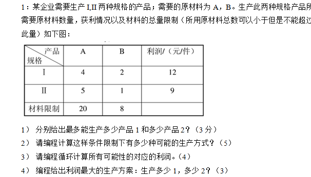

```python
from IPython.display import Image
Image("1123.png")
```